# Creating block diagram

```python
!pip uninstall blockdiag
```

[output not shown]

[output cut: 267 more lines]

[output not shown]

## Install the blockdiag library

We will use the [blockdiag](http://blockdiag.com/en/blockdiag/) library to easily create a block diagram to insert in the Jupyter notebook.

```python
!pip install blockdiag
```

```
    100% |████████████████████████████████| 2.7MB 231kB/s ta 0:00:011
  Running setup.py bdist_wheel for funcparserlib ... - \ | / - \ done
  Running setup.py bdist_wheel for webcolors ... - \ done
```

## Diagram definition

First we create the folder:

```python
!mkdir diagrams
```

and we create a new file inside the `diagrams` folder with the definition of the graph:

```python
%%file diagrams/block_diagram
blockdiag {
  // Define class (list of attributes)
  class emphasis [color = lightblue, style = dashed];
  class redline [color = red, style = dotted];

  Extract -> Transform -> Load;

  // Set class to node
  Transform [class = "emphasis"];

  // Set class to edge
  Transform -> Load [class = "redline"];
}
```

```
Writing diagrams/block_diagram
```

## Convert the diagram to PNG

Using the `blockdiag` library, we can convert the diagram from the definition to a PNG by running the `blockdiag` command from the command line with the graph definition as first argument:

```python
!blockdiag diagrams/block_diagram
```

## Display the PNG

By using the display functionality of the Jupyter notebook we can show the generated PNG:

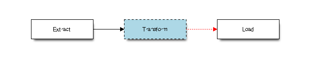

```python
from IPython.display import Image
Image("diagrams/block_diagram.png")
```

## Convert to slides

Jupyter has the functionality to convert a Jupyter notebook to a fancy looking presentation. By using `nbconvert` and with the output set to `slides`, the notebook will be translated to an HTML page, which will be transformed into a beautiful presentation by adding the [RevealJS](https://revealjs.com/#/) library.

```python
!jupyter nbconvert creating_block_diagram.ipynb --to slides
```

```
[NbConvertApp] Converting notebook creating_block_diagram.ipynb to slides
[NbConvertApp] Writing 267690 bytes to creating_block_diagram.slides.html
```

## Check for resulting HTML

After conversion we should see both the .ipynb and .html in the directory.

```python
!ls -la creating_block_diagram.slides.html
```

[output not shown]

## Retrieve RevealJS

To use Jupyter slides we need to download RevealJS to the root directory of the notebooks. We do this by cloning the `reveal.js` Git repository directly in the current folder.

```python
!git clone https://github.com/hakimel/reveal.js.git
```

```
fatal: destination path 'reveal.js' already exists and is not an empty directory.
```

## Start Python webserver

Use `http.server` for Python 3 and `SimpleHTTPServer` when using Python 2 to start the server to view the HTML page.

```python
!python -m http.server 8000
```

```
Serving HTTP on 0.0.0.0 port 8000 (http://0.0.0.0:8000/) ...
127.0.0.1 - - [15/Jan/2018 00:39:52] code 404, message File not found
127.0.0.1 - - [15/Jan/2018 00:39:52] "GET /view/work/Create%20block%20diagram.slides.html HTTP/1.1" 404 -
127.0.0.1 - - [15/Jan/2018 00:39:53] code 404, message File not found
127.0.0.1 - - [15/Jan/2018 00:39:53] "GET /favicon.ico HTTP/1.1" 404 -
127.0.0.1 - - [15/Jan/2018 00:41:01] "GET / HTTP/1.1" 200 -
127.0.0.1 - - [15/Jan/2018 00:41:04] "GET /creating_block_diagram.slides.html HTTP/1.1" 200 -
127.0.0.1 - - [15/Jan/2018 00:41:05] "GET /reveal.js/css/reveal.css HTTP/1.1" 200 -
127.0.0.1 - - [15/Jan/2018 00:41:05] "GET /reveal.js/css/theme/simple.css HTTP/1.1" 200 -
127.0.0.1 - - [15/Jan/2018 00:41:05] code 404, message File not found
127.0.0.1 - - [15/Jan/2018 00:41:05] "GET /custom.css HTTP/1.1" 404 -
127.0.0.1 - - [15/Jan/2018 00:41:06] "GET /reveal.js/lib/js/head.min.js HTTP/1.1" 200 -
127.0.0.1 - - [15/Jan/2018 00:41:06] "GET /reveal.js/js/reveal.js HTTP/1.1" 200 -
127.0.0.1 - - [15/Jan/2018 00:41:06] "GET /reveal.js/plugin/notes/notes.js HTTP/1.1" 200 -
^C

Keyboard interrupt received, exiting.
```

Check port 8000 and open the HTML page containing the slides. In this case the HTML of this notebook will be visible on http://localhost:8000/creating_block_diagram.slides.html#/.